# 13_mass_spring_period

## 13_mass_spring_period

#### Question

1. The canonical example of [simple harmonic motion](https://en.wikipedia.org/wiki/Simple_harmonic_motion) is a mass-spring system. A lightweight spring is attached to a ceiling, and a moderately heavy mass is attached to the dangling end. If the mass is pulled away from its resting elevation, and released, the weight will bounce up and down, approximately following a sinusoidal function in time. By placing the mass-spring system close to a marked wall, and by using a camera with a long [focal length](https://en.wikipedia.org/wiki/Focal_length#In_photography), the position (in meters above floor) of the mass was tracked over time (in seconds).

   Of course, in order to exactly follow a sinusoidal path through time, a few unrealistic assumptions need to be true. There should be no friction (no air resistance nor internal resistance of the bending spring). Also, the spring should exactly follow [Hooke’s law](https://en.wikipedia.org/wiki/Hooke%27s_law).

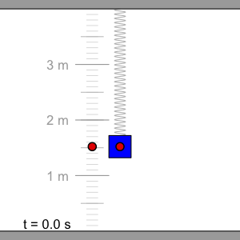

   After capturing the video, elevation measurements were recorded every 0.1 seconds over an interval of 5 seconds.

   | $t$ (time in seconds) | $y$ (height in meters) |
   | --- | --- |
   | 0.0 | 1.52 |
   | 0.1 | 1.51 |
   | 0.2 | 1.49 |
   | 0.3 | 1.44 |
   | 0.4 | 1.35 |
   | 0.5 | 1.25 |
   | 0.6 | 1.14 |
   | 0.7 | 1.07 |
   | 0.8 | 0.99 |
   | 0.9 | 0.89 |
   | 1.0 | 0.80 |
   | 1.1 | 0.72 |
   | 1.2 | 0.64 |
   | 1.3 | 0.59 |
   | 1.4 | 0.58 |
   | 1.5 | 0.57 |
   | 1.6 | 0.55 |
   | 1.7 | 0.61 |
   | 1.8 | 0.65 |
   | 1.9 | 0.68 |
   | 2.0 | 0.81 |
   | 2.1 | 0.85 |
   | 2.2 | 0.99 |
   | 2.3 | 1.12 |
   | 2.4 | 1.20 |
   | 2.5 | 1.27 |
   | 2.6 | 1.39 |
   | 2.7 | 1.44 |
   | 2.8 | 1.45 |
   | 2.9 | 1.53 |
   | 3.0 | 1.51 |
   | 3.1 | 1.50 |
   | 3.2 | 1.44 |
   | 3.3 | 1.44 |
   | 3.4 | 1.33 |
   | 3.5 | 1.30 |
   | 3.6 | 1.18 |
   | 3.7 | 1.04 |
   | 3.8 | 0.99 |
   | 3.9 | 0.88 |
   | 4.0 | 0.79 |
   | 4.1 | 0.71 |
   | 4.2 | 0.66 |
   | 4.3 | 0.54 |
   | 4.4 | 0.55 |
   | 4.5 | 0.54 |
   | 4.6 | 0.58 |
   | 4.7 | 0.59 |
   | 4.8 | 0.66 |
   | 4.9 | 0.72 |
   | 5.0 | 0.76 |

   1. Run a sinusoidal regression on the data.
   2. The regression will have the form $y = A\sin(Bt+C)+D$, where the parameters are $A$, $B$, $C$, and $D$, which are the amplitude, [angular frequency](https://en.wikipedia.org/wiki/Angular_frequency), phase shift, and vertical offset (or midline constant).
   3. Using the angular frequency, calculate the [period](https://en.wikipedia.org/wiki/Periodic_function) ($P$) using $P=\frac{2\pi}{B}$.

   Using the process outlined above, report the period of the best-fit curve. The tolerance is $\pm 0.001$ seconds.

#### Question

2. The canonical example of [simple harmonic motion](https://en.wikipedia.org/wiki/Simple_harmonic_motion) is a mass-spring system. A lightweight spring is attached to a ceiling, and a moderately heavy mass is attached to the dangling end. If the mass is pulled away from its resting elevation, and released, the weight will bounce up and down, approximately following a sinusoidal function in time. By placing the mass-spring system close to a marked wall, and by using a camera with a long [focal length](https://en.wikipedia.org/wiki/Focal_length#In_photography), the position (in meters above floor) of the mass was tracked over time (in seconds).

   Of course, in order to exactly follow a sinusoidal path through time, a few unrealistic assumptions need to be true. There should be no friction (no air resistance nor internal resistance of the bending spring). Also, the spring should exactly follow [Hooke’s law](https://en.wikipedia.org/wiki/Hooke%27s_law).

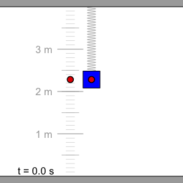

   After capturing the video, elevation measurements were recorded every 0.1 seconds over an interval of 5 seconds.

   | $t$ (time in seconds) | $y$ (height in meters) |
   | --- | --- |
   | 0.0 | 2.31 |
   | 0.1 | 2.22 |
   | 0.2 | 1.98 |
   | 0.3 | 1.73 |
   | 0.4 | 1.41 |
   | 0.5 | 1.19 |
   | 0.6 | 0.99 |
   | 0.7 | 0.88 |
   | 0.8 | 1.00 |
   | 0.9 | 1.16 |
   | 1.0 | 1.46 |
   | 1.1 | 1.81 |
   | 1.2 | 2.09 |
   | 1.3 | 2.26 |
   | 1.4 | 2.30 |
   | 1.5 | 2.17 |
   | 1.6 | 1.94 |
   | 1.7 | 1.72 |
   | 1.8 | 1.38 |
   | 1.9 | 1.11 |
   | 2.0 | 0.96 |
   | 2.1 | 0.93 |
   | 2.2 | 1.00 |
   | 2.3 | 1.21 |
   | 2.4 | 1.49 |
   | 2.5 | 1.80 |
   | 2.6 | 2.07 |
   | 2.7 | 2.27 |
   | 2.8 | 2.27 |
   | 2.9 | 2.17 |
   | 3.0 | 1.91 |
   | 3.1 | 1.68 |
   | 3.2 | 1.31 |
   | 3.3 | 1.13 |
   | 3.4 | 0.90 |
   | 3.5 | 0.92 |
   | 3.6 | 0.99 |
   | 3.7 | 1.28 |
   | 3.8 | 1.53 |
   | 3.9 | 1.83 |
   | 4.0 | 2.14 |
   | 4.1 | 2.23 |
   | 4.2 | 2.27 |
   | 4.3 | 2.11 |
   | 4.4 | 1.89 |
   | 4.5 | 1.61 |
   | 4.6 | 1.29 |
   | 4.7 | 1.02 |
   | 4.8 | 0.96 |
   | 4.9 | 0.93 |
   | 5.0 | 1.06 |

   1. Run a sinusoidal regression on the data.
   2. The regression will have the form $y = A\sin(Bt+C)+D$, where the parameters are $A$, $B$, $C$, and $D$, which are the amplitude, [angular frequency](https://en.wikipedia.org/wiki/Angular_frequency), phase shift, and vertical offset (or midline constant).
   3. Using the angular frequency, calculate the [period](https://en.wikipedia.org/wiki/Periodic_function) ($P$) using $P=\frac{2\pi}{B}$.

   Using the process outlined above, report the period of the best-fit curve. The tolerance is $\pm 0.001$ seconds.

#### Question

3. The canonical example of [simple harmonic motion](https://en.wikipedia.org/wiki/Simple_harmonic_motion) is a mass-spring system. A lightweight spring is attached to a ceiling, and a moderately heavy mass is attached to the dangling end. If the mass is pulled away from its resting elevation, and released, the weight will bounce up and down, approximately following a sinusoidal function in time. By placing the mass-spring system close to a marked wall, and by using a camera with a long [focal length](https://en.wikipedia.org/wiki/Focal_length#In_photography), the position (in meters above floor) of the mass was tracked over time (in seconds).

   Of course, in order to exactly follow a sinusoidal path through time, a few unrealistic assumptions need to be true. There should be no friction (no air resistance nor internal resistance of the bending spring). Also, the spring should exactly follow [Hooke’s law](https://en.wikipedia.org/wiki/Hooke%27s_law).

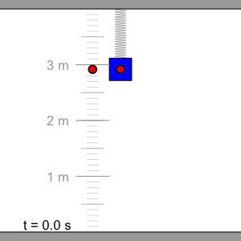

   After capturing the video, elevation measurements were recorded every 0.1 seconds over an interval of 5 seconds.

   | $t$ (time in seconds) | $y$ (height in meters) |
   | --- | --- |
   | 0.0 | 2.89 |
   | 0.1 | 2.84 |
   | 0.2 | 2.76 |
   | 0.3 | 2.54 |
   | 0.4 | 2.21 |
   | 0.5 | 1.94 |
   | 0.6 | 1.60 |
   | 0.7 | 1.30 |
   | 0.8 | 1.11 |
   | 0.9 | 1.01 |
   | 1.0 | 1.00 |
   | 1.1 | 1.04 |
   | 1.2 | 1.26 |
   | 1.3 | 1.47 |
   | 1.4 | 1.74 |
   | 1.5 | 2.03 |
   | 1.6 | 2.40 |
   | 1.7 | 2.61 |
   | 1.8 | 2.83 |
   | 1.9 | 2.93 |
   | 2.0 | 2.94 |
   | 2.1 | 2.79 |
   | 2.2 | 2.66 |
   | 2.3 | 2.39 |
   | 2.4 | 2.04 |
   | 2.5 | 1.73 |
   | 2.6 | 1.50 |
   | 2.7 | 1.21 |
   | 2.8 | 1.10 |
   | 2.9 | 0.97 |
   | 3.0 | 1.05 |
   | 3.1 | 1.12 |
   | 3.2 | 1.34 |
   | 3.3 | 1.58 |
   | 3.4 | 1.87 |
   | 3.5 | 2.24 |
   | 3.6 | 2.49 |
   | 3.7 | 2.74 |
   | 3.8 | 2.85 |
   | 3.9 | 2.95 |
   | 4.0 | 2.91 |
   | 4.1 | 2.73 |
   | 4.2 | 2.47 |
   | 4.3 | 2.26 |
   | 4.4 | 1.92 |
   | 4.5 | 1.64 |
   | 4.6 | 1.31 |
   | 4.7 | 1.17 |
   | 4.8 | 1.00 |
   | 4.9 | 0.95 |
   | 5.0 | 1.07 |

   1. Run a sinusoidal regression on the data.
   2. The regression will have the form $y = A\sin(Bt+C)+D$, where the parameters are $A$, $B$, $C$, and $D$, which are the amplitude, [angular frequency](https://en.wikipedia.org/wiki/Angular_frequency), phase shift, and vertical offset (or midline constant).
   3. Using the angular frequency, calculate the [period](https://en.wikipedia.org/wiki/Periodic_function) ($P$) using $P=\frac{2\pi}{B}$.

   Using the process outlined above, report the period of the best-fit curve. The tolerance is $\pm 0.001$ seconds.

#### Question

4. The canonical example of [simple harmonic motion](https://en.wikipedia.org/wiki/Simple_harmonic_motion) is a mass-spring system. A lightweight spring is attached to a ceiling, and a moderately heavy mass is attached to the dangling end. If the mass is pulled away from its resting elevation, and released, the weight will bounce up and down, approximately following a sinusoidal function in time. By placing the mass-spring system close to a marked wall, and by using a camera with a long [focal length](https://en.wikipedia.org/wiki/Focal_length#In_photography), the position (in meters above floor) of the mass was tracked over time (in seconds).

   Of course, in order to exactly follow a sinusoidal path through time, a few unrealistic assumptions need to be true. There should be no friction (no air resistance nor internal resistance of the bending spring). Also, the spring should exactly follow [Hooke’s law](https://en.wikipedia.org/wiki/Hooke%27s_law).

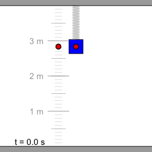

   After capturing the video, elevation measurements were recorded every 0.1 seconds over an interval of 5 seconds.

   | $t$ (time in seconds) | $y$ (height in meters) |
   | --- | --- |
   | 0.0 | 2.80 |
   | 0.1 | 2.75 |
   | 0.2 | 2.47 |
   | 0.3 | 2.00 |
   | 0.4 | 1.59 |
   | 0.5 | 1.27 |
   | 0.6 | 0.99 |
   | 0.7 | 1.01 |
   | 0.8 | 1.17 |
   | 0.9 | 1.57 |
   | 1.0 | 1.99 |
   | 1.1 | 2.42 |
   | 1.2 | 2.67 |
   | 1.3 | 2.87 |
   | 1.4 | 2.79 |
   | 1.5 | 2.53 |
   | 1.6 | 2.09 |
   | 1.7 | 1.63 |
   | 1.8 | 1.30 |
   | 1.9 | 1.05 |
   | 2.0 | 0.96 |
   | 2.1 | 1.14 |
   | 2.2 | 1.48 |
   | 2.3 | 1.88 |
   | 2.4 | 2.32 |
   | 2.5 | 2.68 |
   | 2.6 | 2.81 |
   | 2.7 | 2.79 |
   | 2.8 | 2.56 |
   | 2.9 | 2.15 |
   | 3.0 | 1.73 |
   | 3.1 | 1.32 |
   | 3.2 | 1.03 |
   | 3.3 | 0.94 |
   | 3.4 | 1.12 |
   | 3.5 | 1.45 |
   | 3.6 | 1.86 |
   | 3.7 | 2.29 |
   | 3.8 | 2.61 |
   | 3.9 | 2.84 |
   | 4.0 | 2.81 |
   | 4.1 | 2.59 |
   | 4.2 | 2.22 |
   | 4.3 | 1.80 |
   | 4.4 | 1.36 |
   | 4.5 | 1.10 |
   | 4.6 | 0.97 |
   | 4.7 | 1.11 |
   | 4.8 | 1.32 |
   | 4.9 | 1.80 |
   | 5.0 | 2.17 |

   1. Run a sinusoidal regression on the data.
   2. The regression will have the form $y = A\sin(Bt+C)+D$, where the parameters are $A$, $B$, $C$, and $D$, which are the amplitude, [angular frequency](https://en.wikipedia.org/wiki/Angular_frequency), phase shift, and vertical offset (or midline constant).
   3. Using the angular frequency, calculate the [period](https://en.wikipedia.org/wiki/Periodic_function) ($P$) using $P=\frac{2\pi}{B}$.

   Using the process outlined above, report the period of the best-fit curve. The tolerance is $\pm 0.001$ seconds.

#### Question

5. The canonical example of [simple harmonic motion](https://en.wikipedia.org/wiki/Simple_harmonic_motion) is a mass-spring system. A lightweight spring is attached to a ceiling, and a moderately heavy mass is attached to the dangling end. If the mass is pulled away from its resting elevation, and released, the weight will bounce up and down, approximately following a sinusoidal function in time. By placing the mass-spring system close to a marked wall, and by using a camera with a long [focal length](https://en.wikipedia.org/wiki/Focal_length#In_photography), the position (in meters above floor) of the mass was tracked over time (in seconds).

   Of course, in order to exactly follow a sinusoidal path through time, a few unrealistic assumptions need to be true. There should be no friction (no air resistance nor internal resistance of the bending spring). Also, the spring should exactly follow [Hooke’s law](https://en.wikipedia.org/wiki/Hooke%27s_law).

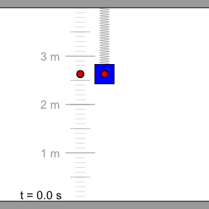

   After capturing the video, elevation measurements were recorded every 0.1 seconds over an interval of 5 seconds.

   | $t$ (time in seconds) | $y$ (height in meters) |
   | --- | --- |
   | 0.0 | 2.67 |
   | 0.1 | 2.55 |
   | 0.2 | 2.34 |
   | 0.3 | 2.10 |
   | 0.4 | 1.70 |
   | 0.5 | 1.41 |
   | 0.6 | 1.07 |
   | 0.7 | 0.84 |
   | 0.8 | 0.68 |
   | 0.9 | 0.71 |
   | 1.0 | 0.88 |
   | 1.1 | 1.14 |
   | 1.2 | 1.42 |
   | 1.3 | 1.80 |
   | 1.4 | 2.13 |
   | 1.5 | 2.39 |
   | 1.6 | 2.58 |
   | 1.7 | 2.59 |
   | 1.8 | 2.54 |
   | 1.9 | 2.37 |
   | 2.0 | 2.03 |
   | 2.1 | 1.67 |
   | 2.2 | 1.33 |
   | 2.3 | 1.03 |
   | 2.4 | 0.76 |
   | 2.5 | 0.66 |
   | 2.6 | 0.76 |
   | 2.7 | 0.86 |
   | 2.8 | 1.17 |
   | 2.9 | 1.50 |
   | 3.0 | 1.86 |
   | 3.1 | 2.18 |
   | 3.2 | 2.41 |
   | 3.3 | 2.63 |
   | 3.4 | 2.63 |
   | 3.5 | 2.54 |
   | 3.6 | 2.26 |
   | 3.7 | 1.97 |
   | 3.8 | 1.63 |
   | 3.9 | 1.24 |
   | 4.0 | 1.01 |
   | 4.1 | 0.75 |
   | 4.2 | 0.67 |
   | 4.3 | 0.71 |
   | 4.4 | 0.91 |
   | 4.5 | 1.20 |
   | 4.6 | 1.56 |
   | 4.7 | 1.88 |
   | 4.8 | 2.18 |
   | 4.9 | 2.49 |
   | 5.0 | 2.61 |

   1. Run a sinusoidal regression on the data.
   2. The regression will have the form $y = A\sin(Bt+C)+D$, where the parameters are $A$, $B$, $C$, and $D$, which are the amplitude, [angular frequency](https://en.wikipedia.org/wiki/Angular_frequency), phase shift, and vertical offset (or midline constant).
   3. Using the angular frequency, calculate the [period](https://en.wikipedia.org/wiki/Periodic_function) ($P$) using $P=\frac{2\pi}{B}$.

   Using the process outlined above, report the period of the best-fit curve. The tolerance is $\pm 0.001$ seconds.

#### Question

6. The canonical example of [simple harmonic motion](https://en.wikipedia.org/wiki/Simple_harmonic_motion) is a mass-spring system. A lightweight spring is attached to a ceiling, and a moderately heavy mass is attached to the dangling end. If the mass is pulled away from its resting elevation, and released, the weight will bounce up and down, approximately following a sinusoidal function in time. By placing the mass-spring system close to a marked wall, and by using a camera with a long [focal length](https://en.wikipedia.org/wiki/Focal_length#In_photography), the position (in meters above floor) of the mass was tracked over time (in seconds).

   Of course, in order to exactly follow a sinusoidal path through time, a few unrealistic assumptions need to be true. There should be no friction (no air resistance nor internal resistance of the bending spring). Also, the spring should exactly follow [Hooke’s law](https://en.wikipedia.org/wiki/Hooke%27s_law).

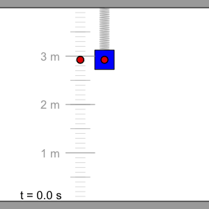

   After capturing the video, elevation measurements were recorded every 0.1 seconds over an interval of 5 seconds.

   | $t$ (time in seconds) | $y$ (height in meters) |
   | --- | --- |
   | 0.0 | 2.90 |
   | 0.1 | 2.76 |
   | 0.2 | 2.28 |
   | 0.3 | 1.62 |
   | 0.4 | 1.09 |
   | 0.5 | 0.64 |
   | 0.6 | 0.60 |
   | 0.7 | 0.85 |
   | 0.8 | 1.35 |
   | 0.9 | 2.03 |
   | 1.0 | 2.59 |
   | 1.1 | 2.92 |
   | 1.2 | 2.90 |
   | 1.3 | 2.50 |
   | 1.4 | 1.97 |
   | 1.5 | 1.33 |
   | 1.6 | 0.78 |
   | 1.7 | 0.58 |
   | 1.8 | 0.66 |
   | 1.9 | 1.07 |
   | 2.0 | 1.75 |
   | 2.1 | 2.37 |
   | 2.2 | 2.80 |
   | 2.3 | 2.89 |
   | 2.4 | 2.74 |
   | 2.5 | 2.21 |
   | 2.6 | 1.59 |
   | 2.7 | 1.01 |
   | 2.8 | 0.62 |
   | 2.9 | 0.56 |
   | 3.0 | 0.86 |
   | 3.1 | 1.42 |
   | 3.2 | 2.06 |
   | 3.3 | 2.62 |
   | 3.4 | 2.89 |
   | 3.5 | 2.81 |
   | 3.6 | 2.46 |
   | 3.7 | 1.84 |
   | 3.8 | 1.28 |
   | 3.9 | 0.79 |
   | 4.0 | 0.54 |
   | 4.1 | 0.72 |
   | 4.2 | 1.18 |
   | 4.3 | 1.79 |
   | 4.4 | 2.37 |
   | 4.5 | 2.82 |
   | 4.6 | 2.91 |
   | 4.7 | 2.68 |
   | 4.8 | 2.14 |
   | 4.9 | 1.54 |
   | 5.0 | 0.91 |

   1. Run a sinusoidal regression on the data.
   2. The regression will have the form $y = A\sin(Bt+C)+D$, where the parameters are $A$, $B$, $C$, and $D$, which are the amplitude, [angular frequency](https://en.wikipedia.org/wiki/Angular_frequency), phase shift, and vertical offset (or midline constant).
   3. Using the angular frequency, calculate the [period](https://en.wikipedia.org/wiki/Periodic_function) ($P$) using $P=\frac{2\pi}{B}$.

   Using the process outlined above, report the period of the best-fit curve. The tolerance is $\pm 0.001$ seconds.

#### Question

7. The canonical example of [simple harmonic motion](https://en.wikipedia.org/wiki/Simple_harmonic_motion) is a mass-spring system. A lightweight spring is attached to a ceiling, and a moderately heavy mass is attached to the dangling end. If the mass is pulled away from its resting elevation, and released, the weight will bounce up and down, approximately following a sinusoidal function in time. By placing the mass-spring system close to a marked wall, and by using a camera with a long [focal length](https://en.wikipedia.org/wiki/Focal_length#In_photography), the position (in meters above floor) of the mass was tracked over time (in seconds).

   Of course, in order to exactly follow a sinusoidal path through time, a few unrealistic assumptions need to be true. There should be no friction (no air resistance nor internal resistance of the bending spring). Also, the spring should exactly follow [Hooke’s law](https://en.wikipedia.org/wiki/Hooke%27s_law).

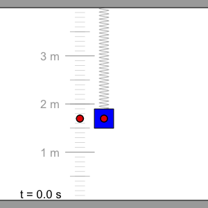

   After capturing the video, elevation measurements were recorded every 0.1 seconds over an interval of 5 seconds.

   | $t$ (time in seconds) | $y$ (height in meters) |
   | --- | --- |
   | 0.0 | 1.67 |
   | 0.1 | 1.61 |
   | 0.2 | 1.51 |
   | 0.3 | 1.28 |
   | 0.4 | 1.07 |
   | 0.5 | 0.81 |
   | 0.6 | 0.68 |
   | 0.7 | 0.54 |
   | 0.8 | 0.55 |
   | 0.9 | 0.62 |
   | 1.0 | 0.81 |
   | 1.1 | 1.03 |
   | 1.2 | 1.31 |
   | 1.3 | 1.50 |
   | 1.4 | 1.61 |
   | 1.5 | 1.66 |
   | 1.6 | 1.65 |
   | 1.7 | 1.52 |
   | 1.8 | 1.29 |
   | 1.9 | 1.07 |
   | 2.0 | 0.88 |
   | 2.1 | 0.68 |
   | 2.2 | 0.53 |
   | 2.3 | 0.57 |
   | 2.4 | 0.65 |
   | 2.5 | 0.80 |
   | 2.6 | 1.07 |
   | 2.7 | 1.23 |
   | 2.8 | 1.46 |
   | 2.9 | 1.60 |
   | 3.0 | 1.71 |
   | 3.1 | 1.68 |
   | 3.2 | 1.50 |
   | 3.3 | 1.37 |
   | 3.4 | 1.08 |
   | 3.5 | 0.84 |
   | 3.6 | 0.67 |
   | 3.7 | 0.57 |
   | 3.8 | 0.55 |
   | 3.9 | 0.64 |
   | 4.0 | 0.80 |
   | 4.1 | 0.98 |
   | 4.2 | 1.25 |
   | 4.3 | 1.49 |
   | 4.4 | 1.66 |
   | 4.5 | 1.67 |
   | 4.6 | 1.63 |
   | 4.7 | 1.57 |
   | 4.8 | 1.33 |
   | 4.9 | 1.10 |
   | 5.0 | 0.88 |

   1. Run a sinusoidal regression on the data.
   2. The regression will have the form $y = A\sin(Bt+C)+D$, where the parameters are $A$, $B$, $C$, and $D$, which are the amplitude, [angular frequency](https://en.wikipedia.org/wiki/Angular_frequency), phase shift, and vertical offset (or midline constant).
   3. Using the angular frequency, calculate the [period](https://en.wikipedia.org/wiki/Periodic_function) ($P$) using $P=\frac{2\pi}{B}$.

   Using the process outlined above, report the period of the best-fit curve. The tolerance is $\pm 0.001$ seconds.

#### Question

8. The canonical example of [simple harmonic motion](https://en.wikipedia.org/wiki/Simple_harmonic_motion) is a mass-spring system. A lightweight spring is attached to a ceiling, and a moderately heavy mass is attached to the dangling end. If the mass is pulled away from its resting elevation, and released, the weight will bounce up and down, approximately following a sinusoidal function in time. By placing the mass-spring system close to a marked wall, and by using a camera with a long [focal length](https://en.wikipedia.org/wiki/Focal_length#In_photography), the position (in meters above floor) of the mass was tracked over time (in seconds).

   Of course, in order to exactly follow a sinusoidal path through time, a few unrealistic assumptions need to be true. There should be no friction (no air resistance nor internal resistance of the bending spring). Also, the spring should exactly follow [Hooke’s law](https://en.wikipedia.org/wiki/Hooke%27s_law).

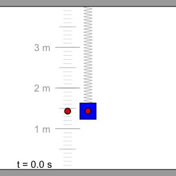

   After capturing the video, elevation measurements were recorded every 0.1 seconds over an interval of 5 seconds.

   | $t$ (time in seconds) | $y$ (height in meters) |
   | --- | --- |
   | 0.0 | 1.45 |
   | 0.1 | 1.45 |
   | 0.2 | 1.37 |
   | 0.3 | 1.26 |
   | 0.4 | 1.06 |
   | 0.5 | 0.92 |
   | 0.6 | 0.79 |
   | 0.7 | 0.69 |
   | 0.8 | 0.52 |
   | 0.9 | 0.47 |
   | 1.0 | 0.43 |
   | 1.1 | 0.44 |
   | 1.2 | 0.58 |
   | 1.3 | 0.63 |
   | 1.4 | 0.77 |
   | 1.5 | 0.96 |
   | 1.6 | 1.08 |
   | 1.7 | 1.25 |
   | 1.8 | 1.35 |
   | 1.9 | 1.37 |
   | 2.0 | 1.40 |
   | 2.1 | 1.38 |
   | 2.2 | 1.38 |
   | 2.3 | 1.27 |
   | 2.4 | 1.15 |
   | 2.5 | 0.98 |
   | 2.6 | 0.83 |
   | 2.7 | 0.72 |
   | 2.8 | 0.55 |
   | 2.9 | 0.47 |
   | 3.0 | 0.46 |
   | 3.1 | 0.46 |
   | 3.2 | 0.52 |
   | 3.3 | 0.65 |
   | 3.4 | 0.75 |
   | 3.5 | 0.93 |
   | 3.6 | 1.06 |
   | 3.7 | 1.21 |
   | 3.8 | 1.32 |
   | 3.9 | 1.38 |
   | 4.0 | 1.45 |
   | 4.1 | 1.45 |
   | 4.2 | 1.38 |
   | 4.3 | 1.23 |
   | 4.4 | 1.09 |
   | 4.5 | 0.95 |
   | 4.6 | 0.82 |
   | 4.7 | 0.71 |
   | 4.8 | 0.55 |
   | 4.9 | 0.52 |
   | 5.0 | 0.50 |

   1. Run a sinusoidal regression on the data.
   2. The regression will have the form $y = A\sin(Bt+C)+D$, where the parameters are $A$, $B$, $C$, and $D$, which are the amplitude, [angular frequency](https://en.wikipedia.org/wiki/Angular_frequency), phase shift, and vertical offset (or midline constant).
   3. Using the angular frequency, calculate the [period](https://en.wikipedia.org/wiki/Periodic_function) ($P$) using $P=\frac{2\pi}{B}$.

   Using the process outlined above, report the period of the best-fit curve. The tolerance is $\pm 0.001$ seconds.